# Community Contribution: Plot Diverging Stacked Bar Chart with `ggplot2`

Kun Tao

October 29 2018

## I Introduction

`ggplot2` is a powerful R package for data visualization. However, I found it quite challenging to draw a Diverging Stacked Bar Chart for data from Likert-Type Scales by using `ggplot2`. Inspired by Prof. Robbins’ proposal in her lecture, I decided to have a try. Finally, after careful research, I found an approach to plot this type of bar graph with `ggplot2` and would like to present it as my Community Contribution.

## II Data Description

The dataset used to draw the Diverging Stacked Bar Chart of interest is `gender.csv`. First, let me load packages `tidyverse` and `reshape2` into R. Then load `gender.csv` into the dataframe `df_gender` and have a quick check of its structure and display its contents. As we see, the dataset is Likert-type and has 5 observations, and 4 variables which are: `Group`, `Hasn't gone far enough`, `Has been about right` and `Has gone too far`. Variable `Group` has five categories: `All adults`, `Men`, `Women`, `Rep/Lean Rep`, `Dem/Lean Dem`, whereas the rest three variables respectively show what is the percentage of the surveyed people in each category think that it `Hasn't gone far enough`, or `Has been about right`, or `Has gone too far` when it comes to giving women equal rights with men. The goal of this presentation is to visualize the patterns with a Diverging Stacked Bar Chart by using `ggplot2`.

```r
library(tidyverse)
library(reshape2)


df_gender <- read.csv("gender.csv", header = TRUE, check.names = FALSE, fileEncoding = "UTF-8-BOM")
str(df_gender)
```

```
## 'data.frame':    5 obs. of  4 variables:
##  $ Group                 : Factor w/ 5 levels "All adults","Dem/Lean Dem",..: 1 3 5 4 2
##  $ Hasn't gone far enough: int  50 42 57 26 69
##  $ Has been about right  : int  39 44 33 54 26
##  $ Has gone too far      : int  10 13 8 18 4
```

```r
df_gender
```

| Group | Hasn't gone far enough | Has been about right | Has gone too far |
| --- | --- | --- | --- |
| All adults | 50 | 39 | 10 |
| Men | 42 | 44 | 13 |
| Women | 57 | 33 | 8 |
| Rep/Lean Rep | 26 | 54 | 18 |
| Dem/Lean Dem | 69 | 26 | 4 |

## III Draw Diverging Stacked Bar Chart with *Neutral* Option Kept by Using `ggplot2`

### 3.1 Version I

In order to plot the Diverging Stacked Bar Chart with *Neutral* Option Kept by Using `ggplot2`, I need to do some preprocessing and create a new dataframe `df1`. First, I split values in the `Has been about right` in half and further create two new columns `Has been about right_PosHalf` and `Has been about right_NegHalf`, then drop the `Has been about right` column. Next, change all values in the `Has gone too far` into negatives and rearrange all columns of `df1` in a order in favor of making the desired plot. Finally, change `df1` to a long format `df1_long` and draw the *Diverging stacked bar chart plotted by ggplot Version I* as shown below.

The graph looks pretty well except one thing with which I am not very satisfied: the legend shows `Has been about right` twice. That is because the built-in function `ggplot` and `geom_bar` make the drawing in such an order: first draw the part which represents `Hasn't gone far enough`, then `Has been about right_PosHalf`, next `Has gone too far` and finally `Has been about right_NegHalf`, whereas both `Has been about right_PosHalf` and `Has been about right_NegHalf` have been labeled as `Has been about right` in the legend.

```r
df1 <- df_gender
df1["Has been about right_PosHalf"] <- df1["Has been about right"] / 2
df1["Has been about right_NegHalf"] <- -df1["Has been about right"] / 2
df1["Has been about right"] <- NULL

df1["Has gone too far"] <- -df1["Has gone too far"]

df1 <- df1[c("Group", "Hasn't gone far enough", "Has been about right_PosHalf",
             "Has gone too far", "Has been about right_NegHalf")]

df1_long <- melt(df1, id.vars = c("Group"))
colnames(df1_long)[2] <- c("Response")
colnames(df1_long)[3] <- c("Percent")
df1_long <- df1_long[c("Group", "Response", "Percent")]

str(df1_long)
```

```
## 'data.frame':    20 obs. of  3 variables:
##  $ Group   : Factor w/ 5 levels "All adults","Dem/Lean Dem",..: 1 3 5 4 2 1 3 5 4 2 ...
##  $ Response: Factor w/ 4 levels "Hasn't gone far enough",..: 1 1 1 1 1 2 2 2 2 2 ...
##  $ Percent : num  50 42 57 26 69 19.5 22 16.5 27 13 ...
```

```r
df1_long
```

| Group | Response | Percent |
| --- | --- | --- |
| All adults | Hasn't gone far enough | 50.0 |
| Men | Hasn't gone far enough | 42.0 |
| Women | Hasn't gone far enough | 57.0 |
| Rep/Lean Rep | Hasn't gone far enough | 26.0 |
| Dem/Lean Dem | Hasn't gone far enough | 69.0 |
| All adults | Has been about right_PosHalf | 19.5 |
| Men | Has been about right_PosHalf | 22.0 |
| Women | Has been about right_PosHalf | 16.5 |
| Rep/Lean Rep | Has been about right_PosHalf | 27.0 |
| Dem/Lean Dem | Has been about right_PosHalf | 13.0 |

[output cut: 10 more lines]

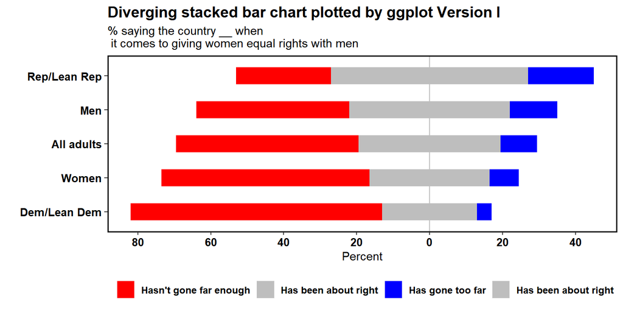

```r
ggplot(df1_long, aes(x = reorder(Group, -Percent), y = Percent, fill = Response)) +
  geom_bar(stat = 'identity', width = 0.5) +
  geom_hline(aes(yintercept = 0.0), color = "grey") +
  scale_y_reverse(breaks = seq(80, -40, -20), labels = c(80, 60, 40, 20, 0, 20, 40)) +
  scale_fill_manual(name = "",
                    labels = c("Hasn't gone far enough", "Has been about right",
                               "Has gone too far", "Has been about right"),
                    values = c("red", "grey", "blue", "grey")) +
  coord_flip() +
  xlab("") +
  ggtitle("Diverging stacked bar chart plotted by ggplot Version I",
          subtitle = "% saying the country __ when \n it comes to giving women equal rights with men") +
  theme(legend.direction = "horizontal", legend.position = "bottom",
        legend.text = element_text(face = "bold", size = 9)) +
  theme(panel.grid = element_blank(),
        panel.background = element_blank(),
        panel.border = element_rect(colour = "black", fill = NA, size = 1)) +
  theme(axis.text.x = element_text(face = "bold", color = "black", size = 10),
        axis.text.y = element_text(face = "bold", color = "black", size = 10)) +
  theme(plot.title = element_text(face = "bold", size = 14))
```

### 3.2 Version II

Now, I am eliminating the extra legend text of `Has been about right` in the above graph by setting `fill` in `ggplot` as `colFill` which only corresponds to three cases: `Hasn't gone far enough`, `Has gone too far` and `Has been about right`, then I get the Diverging stacked bar chart plotted by ggplot Version II below, which looks just right.

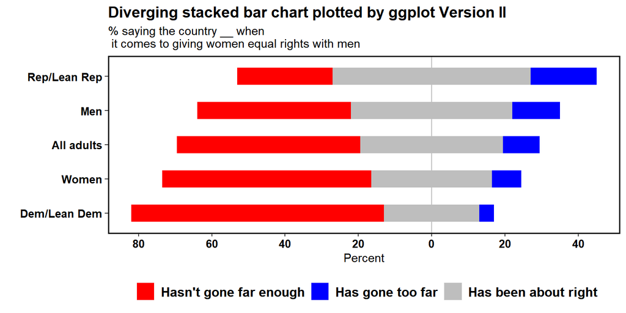

```r
colFill <- ifelse( (df1_long$Response == "Hasn't gone far enough"), "1",
                   ifelse( (df1_long$Response == "Has gone too far"), "2", "3"))


ggplot(df1_long, aes(x = reorder(Group, -Percent), y = Percent, fill = colFill)) +
  geom_bar(stat = 'identity', width = 0.5) +
  geom_hline(aes(yintercept = 0.0), color = "grey") +
  scale_y_reverse(breaks = seq(80, -40, -20), labels = c(80, 60, 40, 20, 0, 20, 40)) +
  scale_fill_manual(name = "",
                    labels = c("Hasn't gone far enough", "Has gone too far", "Has been about right"),
                    values = c("red", "blue", "grey")) +
  coord_flip() +
  xlab("") +
  ggtitle("Diverging stacked bar chart plotted by ggplot Version II",
          subtitle = "% saying the country __ when \n it comes to giving women equal rights with men") +
  theme(legend.direction = "horizontal", legend.position = "bottom",
        legend.text = element_text(face = "bold", size = 12)) +
  theme(panel.grid = element_blank(),
        panel.background = element_blank(),
        panel.border = element_rect(colour = "black", fill = NA, size = 1)) +
  theme(axis.text.x = element_text(face = "bold", color = "black", size = 10),
        axis.text.y = element_text(face = "bold", color = "black", size = 10)) +
  theme(plot.title = element_text(face = "bold", size = 14))
```

## IV Draw Diverging Stacked Bar Chart with *Neutral* Option Removed by Using `ggplot2`

Compared with keeping the `Neutral`, it is relatively easy to plot a Diverging Stacked Bar Chart with *Neutral* option removed by using `ggplot2`. The key lies in dropping the `Has been about right` column and setting all values in the `Has gone too far` column from positives to negatives. The graph of interest is shown as follows.

```r
df2 <- df_gender
df2["Has been about right"] <- NULL
df2["Has gone too far"] <- -df2["Has gone too far"]

df2_long <- melt(df2, id.vars = c("Group"))
colnames(df2_long)[2] <- c("Response")
colnames(df2_long)[3] <- c("Percent")

df2_long
```

| Group | Response | Percent |
| --- | --- | --- |
| All adults | Hasn't gone far enough | 50 |
| Men | Hasn't gone far enough | 42 |
| Women | Hasn't gone far enough | 57 |
| Rep/Lean Rep | Hasn't gone far enough | 26 |
| Dem/Lean Dem | Hasn't gone far enough | 69 |
| All adults | Has gone too far | -10 |
| Men | Has gone too far | -13 |
| Women | Has gone too far | -8 |
| Rep/Lean Rep | Has gone too far | -18 |
| Dem/Lean Dem | Has gone too far | -4 |

[figure not shown]

```r
ggplot(df2_long, aes(x = reorder(Group, -Percent), y = Percent, fill = Response)) +
  geom_bar(stat = 'identity', width = 0.5) +
  geom_hline(aes(yintercept = 0.0)) +
  scale_y_reverse(breaks = seq(80, -20, -20), labels = c(80, 60, 40, 20, 0, 20)) +
  scale_fill_manual(name = "", labels = c("Hasn't gone far enough", "Has gone too far"), values = c("red", "blue")) +
  coord_flip() +
  xlab("") +
  ggtitle("Diverging stacked bar chart plotted by ggplot (neutrals removed)",
          subtitle = "% saying the country __ when \n it comes to giving women equal rights with men") +
  theme(legend.direction = "horizontal", legend.position = "bottom") +
  theme(panel.grid = element_blank(),
        panel.background = element_blank(),
        panel.border = element_rect(colour = "black", fill = NA, size = 1)) +
  theme(axis.text.x = element_text(face = "bold", color = "black", size = 10),
        axis.text.y = element_text(face = "bold", color = "black", size = 10)) +
  theme(text = element_text(face = "bold", size = 12)) +
  theme(plot.title = element_text(face = "bold", size = 14))
```

## V Conclusion

A `ggplot2`-based approach to draw a Diverging Stacked Bar Chart for Likert-Type data with or without *Neutral* kept is presented in this work and the resulting graphs look pretty good.